# Data Arrangement

John Shorter

Feb/21/2024

# Introduction

One important aspect of data analysis is to get the data in the correct format. This is sometimes referred to as getting the data into the tidy format. A tidy dataset is a prerequisite for the downstream data visualization and statistical analyses. Almost always, the first thing you would do when you start a data analysis is to tidy the data first.

In this lesson, you will learn how to use the `dplyr` + `tidyr` packages to achieve tidy datasets from “raw” datasets, as well as basic operations to data tables. We will cover:

As a resource, you can download [the data wrangling cheat sheet](https://rstudio.com/wp-content/uploads/2015/02/data-wrangling-cheatsheet.pdf)

# load packages

You might need to install some of these packages.

```r
library(tidyr) # data arrangement
library(dplyr) # data arrangement
```

```r
library(readr) # reading tab, comma and space separated tables into R
library(readxl) # reading excel into R
library(ggplot2) # R plotting engine
```

These are what we need for now. We will install more as we move into more complex activities. Again the codes in text are highlighted in `grey`.

# Tidy dataset makes your life easy!

First let’s start with an example.  
We can import data from the Environment tab on the right side, or run this command below.  
We can also set a working directory to help us load files. That is done by going to the Session at the top, and choosing Set Working Directory.

```r
C_elegans_DAPI <- read_excel("/work/Data/Rmodule_data/C_elegans_DAPI.xlsx")
head(C_elegans_DAPI)
```

```
## # A tibble: 6 × 8
##   group     A     B     C     D     E     F treatment
##   <dbl> <dbl> <dbl> <dbl> <dbl> <dbl> <dbl> <chr>
## 1     9     6     6     6     6    NA    NA L4440
## 2     8     6     6     6     6    NA    NA L4440
## 3    15     6    NA    NA    NA    NA    NA L4440
## 4    14     6     6     6    NA    NA    NA L4440
## 5    18     6     6     6     6     6     6 L4440
## 6     7     6     6     6    NA    NA    NA L4440
```

This is an experiment conducted by MCB160L (Genetics Labs) students at UC Davis (Spring 2019). In this experiment, there were two students per group. Each group looked at number of DAPI bodies in C. elegans oocyte during meiosis I. They made as much as 6 observations per worm (A - F). The worms were treated with 4 treatments:

1. L4440 = empty vector control (negative control). 2 - 4. RNAi constructs targeting meiotic genes syp-2, rec-8 and zim-1, repectively.

(FYI: In the empty vector control, the expectation was 6 DAPI bodies; there should be more DAPI body in RNAi treated oocytes due to defective pairing or defective synapsis and all that.)

Anyway, that was the experiment, and the results were all recorded in this table.

## Data frames

This table is called a data frame in the jargon of R. A data frame is simply a data table. It has rows and columns. An important aspect of data frame is that rows of the same column must be the same class of variable. For example, in column “A”, all values in column “A” are numeric. In column “treatment”, all values in that column are characters. This is just one thing to keep in mind when working with data frames.

## Tidy data

Not all data frames are tidy. The idea of tidy data means

1. Each row has to be an observation
2. Each column has be a variable

Getting your data into the tidy format will save you *A LOT OF TIME* in all your downstream analyses. A good practice is to tidy your data FIRST before you do any analyses.

Let’s look at this table again:

```r
head(C_elegans_DAPI)
```

```
## # A tibble: 6 × 8
##   group     A     B     C     D     E     F treatment
##   <dbl> <dbl> <dbl> <dbl> <dbl> <dbl> <dbl> <chr>
## 1     9     6     6     6     6    NA    NA L4440
## 2     8     6     6     6     6    NA    NA L4440
## 3    15     6    NA    NA    NA    NA    NA L4440
## 4    14     6     6     6    NA    NA    NA L4440
## 5    18     6     6     6     6     6     6 L4440
## 6     7     6     6     6    NA    NA    NA L4440
```

Is this table a tidy data frame?

No. Because there are up to six observations in each group, but the observations are spread out in 6 columns. Observations spreading out in columns is sometimes called the wide format. The wide format is easy for data collection, but unfortunately it’s not how R would like to read data. R likes tidy data, and tidy data frames need each observation to be in its individual row.

To convert a wide table into a tidy table, the command is `pivot_longer()` The syntax is `pivot_longer(columns, names_to = "name", values_to = "value")`

```r
DAPI_tidy <- C_elegans_DAPI %>% #the %>% ("pipe") operator means taking the output of previous row and use it as input of next row
  pivot_longer(names_to = "observation", values_to = "count", cols = c(A, B, C, D, E, `F`))
#The `F` syntax prevents F to be read as the logical value FALSE by R

DAPI_tidy
```

```
## # A tibble: 456 × 4
##    group treatment observation count
##    <dbl> <chr>     <chr>       <dbl>
##  1     9 L4440     A               6
##  2     9 L4440     B               6
##  3     9 L4440     C               6
##  4     9 L4440     D               6
##  5     9 L4440     E              NA
##  6     9 L4440     F              NA
##  7     8 L4440     A               6
##  8     8 L4440     B               6
##  9     8 L4440     C               6
## 10     8 L4440     D               6
## # ℹ 446 more rows
```

What this code chunk did is that it made two new columns:

1. The “name” column (sometimes called the label column) is “observation”: it houses which original columns the data came from (A - F).
2. The “value” column is “count”: it is the variable that was actually measured.
3. The columns to collect data from were A - F.

Now this is a tidy data frame. Each row is an observation. Each column is a variable. We have 4 variables:

- group,
- treatment (4 treatments),
- observations (A up to F),
- count of DAPI bodies (numeric).

Maybe you have done with before by hand in Excel? By doing this with R, we have removed issues with copy/pasting and have a reproducible method.

# Basic operations to a data frame.

Now let’s talk about some of the basic operations for data frames, which includes:

- How to subset a data frame,
- How to create new columns in a data frame and summarize a data frame.

These are very useful and you will probably use these functions all the time.

## Subsetting

There are actually two ways to subset a data frame: subsetting by columns and subsetting by rows. Let’s do subsetting by columns first.

(NOTE: using select() will also work here, however there was a problem with another library using the select() function and adding dplyr:: in front of select() specifies the correct library.)

```r
head(DAPI_tidy)
```

```
## # A tibble: 6 × 4
##   group treatment observation count
##   <dbl> <chr>     <chr>       <dbl>
## 1     9 L4440     A               6
## 2     9 L4440     B               6
## 3     9 L4440     C               6
## 4     9 L4440     D               6
## 5     9 L4440     E              NA
## 6     9 L4440     F              NA
```

```r
DAPI_tidy_2 <- DAPI_tidy %>%
  dplyr::select(observation, count) #just selecting observation and count

head(DAPI_tidy_2)
```

```
## # A tibble: 6 × 2
##   observation count
##   <chr>       <dbl>
## 1 A               6
## 2 B               6
## 3 C               6
## 4 D               6
## 5 E              NA
## 6 F              NA
```

Now we just get two columns.

The more useful subsetting function is subsetting by rows based on the values of one or more columns. The command is `filter()` In the DAPI experiment, not all groups have all 6 observations. And we only want to keep rows that actually have a count.

```r
DAPI_tidy_3 <- DAPI_tidy %>%
  filter(is.na(count) == FALSE) #filter for rows that the count value is not NA

nrow(DAPI_tidy)
```

```
## [1] 456
```

```r
nrow(DAPI_tidy_3)
```

```
## [1] 205
```

Now the data frame went from 456 rows to 205 rows. So the students actually made a total of 205 observations. Note: in `filter()`, you should use `==` to mean “equal”.

Let’s say we only want the empty vector control:

```r
DAPI_tidy_L4440 <- DAPI_tidy_3 %>%
  filter(treatment == "L4440") # filter out rows that were from the L4440 treatment

nrow(DAPI_tidy_3)
```

```
## [1] 205
```

```r
nrow(DAPI_tidy_L4440)
```

```
## [1] 56
```

Looks like there are 56 observations for the empty vector control.

Let’s say you want to filter for L4440 and rec-8:

```r
DAPI_tidy_L4440_rec <- DAPI_tidy_3 %>%
  filter(treatment == "L4440" |
           treatment == "rec-8")

nrow(DAPI_tidy_3)
```

```
## [1] 205
```

```r
nrow(DAPI_tidy_L4440_rec)
```

```
## [1] 100
```

The vertical bar `|` means “or” in R. In this chunk you are filtering for either L4440 or rec-8.  
You shouldn’t use `&` (“and”) here, because there is no treatment that is both L4440 and rec-8.

## Making new columns

Oftentimes you will need to make new variables based on existing ones. The command is `mutate()`. As a biologist, I don’t think “mutate” sound too intuitive, but it is what it is.

Say in the worm experiment, I want a new column called “count_per_chromosome”. C. elegans has 6 chromosomes but diploid (2 copies each), so count per chromosome will be dividing each count by 12.

```r
DAPI_tidy_chr <- DAPI_tidy_3 %>%
  mutate(count_per_chr = count/12)

head(DAPI_tidy_chr)
```

```
## # A tibble: 6 × 5
##   group treatment observation count count_per_chr
##   <dbl> <chr>     <chr>       <dbl>         <dbl>
## 1     9 L4440     A               6           0.5
## 2     9 L4440     B               6           0.5
## 3     9 L4440     C               6           0.5
## 4     9 L4440     D               6           0.5
## 5     8 L4440     A               6           0.5
## 6     8 L4440     B               6           0.5
```

Now you get a new column called “count_per_chr”. As you can imagine, you can do any mathematical operations to a numerical column within `mutate()`.

Let’s do another example. Say in this worm experiment, groups 1 - 12 were in one classroom, and the rest were in another classroom. I want to have a column that records which room the students were working in.

```r
DAPI_tidy_room <- DAPI_tidy_3 %>%
  mutate(room = case_when(
    group <= 12 ~ "room1",
    group > 12 ~ "room2"
  ))

head(DAPI_tidy_room)
```

```
## # A tibble: 6 × 5
##   group treatment observation count room
##   <dbl> <chr>     <chr>       <dbl> <chr>
## 1     9 L4440     A               6 room1
## 2     9 L4440     B               6 room1
## 3     9 L4440     C               6 room1
## 4     9 L4440     D               6 room1
## 5     8 L4440     A               6 room1
## 6     8 L4440     B               6 room1
```

`case_when()` is an extremely useful command within `mutate()`. The syntax is `case_when(condition ~ outcome)`. In this case, when group <= 12, it applies a value of “room1”, otherwise, it applies a value of “room2”.

## Summarise

Before you do real statistical inference, maybe you want to just take a look at the summary statistics. This can be done easily using the `group_by()` and `summarise()` commands.

Say I would like the average, standard deviation and n of each treatment.

```r
DAPI_tidy_summary <- DAPI_tidy_3 %>%
  group_by(treatment) %>%
  summarise(mean = mean(count),
            sd = sd(count),
            n = n()) %>%
  ungroup()

head(DAPI_tidy_summary)
```

```
## # A tibble: 4 × 4
##   treatment  mean    sd     n
##   <chr>     <dbl> <dbl> <int>
## 1 L4440      6     0       56
## 2 rec-8     15.2   5.57    44
## 3 syp-2     11.2   1.29    54
## 4 zim-1      7.37  1.06    51
```

1. `group_by()` selects which columns you want to summarise from. In this case you just want each treatment to be a group.
2. `summarise()` allows you to call the statistical functions, such as mean, sd, and n.
3. It’s a good practice to `ungroup()` after you are done. Most of the time it doesn’t matter, but it will create problems if you don’t and you try to switch/modify grouping later.

Now you just get 4 rows and 4 columns, each row is a treatment. The summary statistics are what people want to read in publications. However, you would still want to release raw data as a supplemental file.

Say I would like to average the counts for each group and for each treatment. Can I do that?

```r
DAPI_tidy_summary_group <- DAPI_tidy_3 %>%
  group_by(group, treatment) %>%
  summarise(mean = mean(count)) %>%
  ungroup()
head(DAPI_tidy_summary_group)
```

```
## # A tibble: 6 × 3
##   group treatment  mean
##   <dbl> <chr>     <dbl>
## 1     1 L4440      6
## 2     1 rec-8     13
## 3     1 syp-2     11.5
## 4     1 zim-1      8.33
## 5     2 L4440      6
## 6     2 rec-8     10
```

1. This time you need to select group and treatment in `group_by()`. Because you want the mean for each group and each treatment.
2. In `summarise()` you call the mean function.
3. It’s a good practice to `ungroup()` after you are done.

Now each group by treatment combination is a row.

# Basic operations to multiple data frames.

In data analyses, the data might not be all in one file. It is common that the data of interest were recorded in multiple spreadsheets. This is extremely common when you are using data from multiple publications. Each publication may only have one aspect of the data you are interested in. After you download their tables, it’s on you to integrate them into one workable data frame in R.

## Joining

More often you’ll need to add different columns from another data frame. The jargon for that is joining. This sounds abstract, so let’s look at an example.

```r
child_mortality <- read_csv("/work/Data/Rmodule_data/child_mortality_0_5_year_olds_dying_per_1000_born.csv", col_types = cols())
babies_per_woman <- read_csv("/work/Data/Rmodule_data/children_per_woman_total_fertility.csv", col_types = cols())
```

These are two datasets downloaded from the [Gapminder foundation](https://www.gapminder.org/data/). The Gapminder foundation has datasets on life expectancy, economy, education, and population across countries and years. The goal is to remind us not only the “gaps” between developed and developing worlds, but also the amazing continuous improvements of quality of life through time.

1. Child mortality (0 - 5 year old) dying per 1000 born.
2. Births per woman.

These were recorded from year 1800 and projected all the way to 2100.

Let’s look at them.

```r
head(child_mortality)
```

```
## # A tibble: 6 × 302
##   country  `1800` `1801` `1802` `1803` `1804` `1805` `1806` `1807` `1808` `1809`
##   <chr>     <dbl>  <dbl>  <dbl>  <dbl>  <dbl>  <dbl>  <dbl>  <dbl>  <dbl>  <dbl>
## 1 Afghani…    469    469    469    469    469    469    470    470    470    470
## 2 Albania     375    375    375    375    375    375    375    375    375    375
## 3 Algeria     460    460    460    460    460    460    460    460    460    460
## 4 Andorra      NA     NA     NA     NA     NA     NA     NA     NA     NA     NA
## 5 Angola      486    486    486    486    486    486    486    486    486    486
## 6 Antigua…    474    470    466    462    458    455    451    447    444    440
## # ℹ 291 more variables: `1810` <dbl>, `1811` <dbl>, `1812` <dbl>, `1813` <dbl>,
## #   `1814` <dbl>, `1815` <dbl>, `1816` <dbl>, `1817` <dbl>, `1818` <dbl>,
## #   `1819` <dbl>, `1820` <dbl>, `1821` <dbl>, `1822` <dbl>, `1823` <dbl>,
## #   `1824` <dbl>, `1825` <dbl>, `1826` <dbl>, `1827` <dbl>, `1828` <dbl>,
## #   `1829` <dbl>, `1830` <dbl>, `1831` <dbl>, `1832` <dbl>, `1833` <dbl>,
## #   `1834` <dbl>, `1835` <dbl>, `1836` <dbl>, `1837` <dbl>, `1838` <dbl>,
## #   `1839` <dbl>, `1840` <dbl>, `1841` <dbl>, `1842` <dbl>, `1843` <dbl>, …
```

```r
head(babies_per_woman)
```

```
## # A tibble: 6 × 302
##   country  `1800` `1801` `1802` `1803` `1804` `1805` `1806` `1807` `1808` `1809`
##   <chr>     <dbl>  <dbl>  <dbl>  <dbl>  <dbl>  <dbl>  <dbl>  <dbl>  <dbl>  <dbl>
## 1 Afghani…   7      7      7      7      7      7      7      7      7      7
## 2 Albania    4.6    4.6    4.6    4.6    4.6    4.6    4.6    4.6    4.6    4.6
## 3 Algeria    6.99   6.99   6.99   6.99   6.99   6.99   6.99   6.99   6.99   6.99
## 4 Angola     6.93   6.93   6.93   6.93   6.93   6.93   6.93   6.94   6.94   6.94
## 5 Antigua…   5      5      4.99   4.99   4.99   4.98   4.98   4.97   4.97   4.97
## 6 Argenti…   6.8    6.8    6.8    6.8    6.8    6.8    6.8    6.8    6.8    6.8
## # ℹ 291 more variables: `1810` <dbl>, `1811` <dbl>, `1812` <dbl>, `1813` <dbl>,
## #   `1814` <dbl>, `1815` <dbl>, `1816` <dbl>, `1817` <dbl>, `1818` <dbl>,
## #   `1819` <dbl>, `1820` <dbl>, `1821` <dbl>, `1822` <dbl>, `1823` <dbl>,
## #   `1824` <dbl>, `1825` <dbl>, `1826` <dbl>, `1827` <dbl>, `1828` <dbl>,
## #   `1829` <dbl>, `1830` <dbl>, `1831` <dbl>, `1832` <dbl>, `1833` <dbl>,
## #   `1834` <dbl>, `1835` <dbl>, `1836` <dbl>, `1837` <dbl>, `1838` <dbl>,
## #   `1839` <dbl>, `1840` <dbl>, `1841` <dbl>, `1842` <dbl>, `1843` <dbl>, …
```

In each table, you have a column for country. Then each year is a column, in which the numbers were recorded for the respective tables.

Say you want to know if births per woman is correlated with child mortality. You may hypothesize that in countries with high child mortality, women give more birth.

To test this hypothesis, you need to first get the two datasets in one data frame. There are a few commands for joining in R:

1. `left_join(X, Y)` keeps all the rows in X.
2. `right_join(X, Y)` keeps all the rows in Y.
3. `inner_join(X, Y)` only keeps rows that are in common.
4. `full_join(X, Y)` keeps all rows, filling in `NA` when values are missing from either one.

Usually, `inner_join()` will work well. When you visualize data you filter out `NA` anyways.

So now let’s inner_join them. But wait…  
These tables are not in the tidy format! The year values are spread out across many columns, so you need to pivot them to “long” or tidy format first.

```r
babies_per_woman_tidy <- babies_per_woman %>%
  pivot_longer(names_to = "year", values_to = "birth", cols = c(2:302))

head(babies_per_woman_tidy)
```

```
## # A tibble: 6 × 3
##   country     year  birth
##   <chr>       <chr> <dbl>
## 1 Afghanistan 1800      7
## 2 Afghanistan 1801      7
## 3 Afghanistan 1802      7
## 4 Afghanistan 1803      7
## 5 Afghanistan 1804      7
## 6 Afghanistan 1805      7
```

```r
child_mortality_tidy <- child_mortality %>%
  pivot_longer(names_to = "year", values_to = "death_per_1000_born", cols = c(2:302))

head(child_mortality_tidy)
```

```
## # A tibble: 6 × 3
##   country     year  death_per_1000_born
##   <chr>       <chr>               <dbl>
## 1 Afghanistan 1800                  469
## 2 Afghanistan 1801                  469
## 3 Afghanistan 1802                  469
## 4 Afghanistan 1803                  469
## 5 Afghanistan 1804                  469
## 6 Afghanistan 1805                  469
```

Now each table has a year column, a value column (either birth or death). The `c(2:302)` argument in `pivot_longer()` specifies gathering data from 2nd through the 302nd column. Now we can join them.

We will use `X %>% inner_join(Y, by = common columns)` syntax. In this case we have two common columns, country and year. This is asking R to match the countries and years.

```r
birth_and_mortality <- babies_per_woman_tidy %>%
  inner_join(child_mortality_tidy, by = c("country", "year"))

head(birth_and_mortality)
```

```
## # A tibble: 6 × 4
##   country     year  birth death_per_1000_born
##   <chr>       <chr> <dbl>               <dbl>
## 1 Afghanistan 1800      7                 469
## 2 Afghanistan 1801      7                 469
## 3 Afghanistan 1802      7                 469
## 4 Afghanistan 1803      7                 469
## 5 Afghanistan 1804      7                 469
## 6 Afghanistan 1805      7                 469
```

So now you have a table with 4 variables: countries, year, birth per woman and death per 1000 born. Now you have all the data together.

To quickly test our hypothesis that higher morality is correlated with more birth per woman, we can plot it. There are too much data to look at, but let’s just pull out the year 1945, when WWII ended.

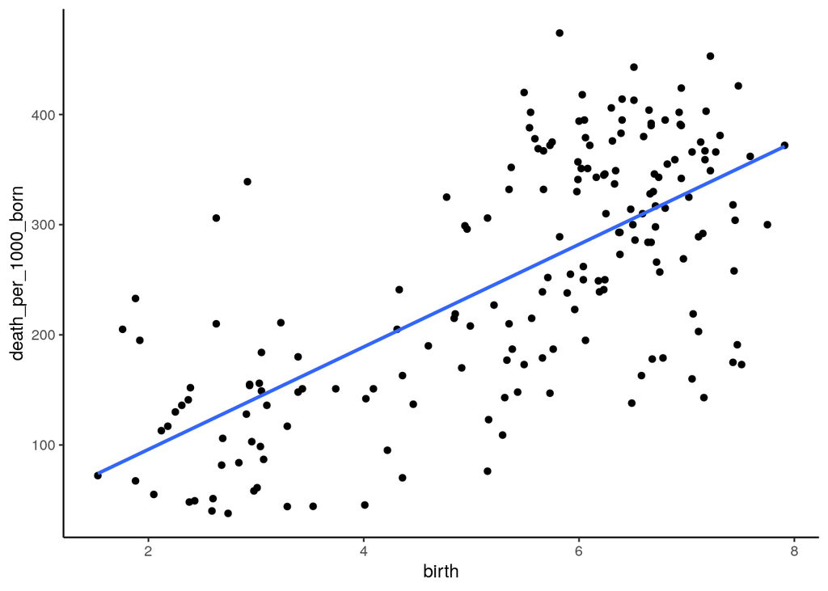

```r
# We will talk about how to use ggplot later, so you can ignore this chunck for now
birth_and_mortality %>%
  filter(year == 1945) %>%
  ggplot(aes(x = birth, y = death_per_1000_born)) +
  geom_point() +
  geom_smooth(method = "lm", se = F) +
  theme_classic()
```

You do see a upward trend, supporting our hypothesis. In countries with higher child mortality, women also tended to give more births.

# Exercise

You have learned data arrangement! Let’s do an exercise to practice what you have learned today. As the example, this time we will use income per person dataset from Gapminder foundation.

```r
income <- read_csv("/work/Data/Rmodule_data/income_per_person_gdppercapita_ppp_inflation_adjusted.csv", col_types = cols())
head(income)
```

```
## # A tibble: 6 × 242
##   country  `1800` `1801` `1802` `1803` `1804` `1805` `1806` `1807` `1808` `1809`
##   <chr>     <dbl>  <dbl>  <dbl>  <dbl>  <dbl>  <dbl>  <dbl>  <dbl>  <dbl>  <dbl>
## 1 Afghani…    603    603    603    603    603    603    603    603    603    603
## 2 Albania     667    667    667    667    667    668    668    668    668    668
## 3 Algeria     715    716    717    718    719    720    721    722    723    724
## 4 Andorra    1200   1200   1200   1200   1210   1210   1210   1210   1220   1220
## 5 Angola      618    620    623    626    628    631    634    637    640    642
## 6 Antigua…    757    757    757    757    757    757    757    758    758    758
## # ℹ 231 more variables: `1810` <dbl>, `1811` <dbl>, `1812` <dbl>, `1813` <dbl>,
## #   `1814` <dbl>, `1815` <dbl>, `1816` <dbl>, `1817` <dbl>, `1818` <dbl>,
## #   `1819` <dbl>, `1820` <dbl>, `1821` <dbl>, `1822` <dbl>, `1823` <dbl>,
## #   `1824` <dbl>, `1825` <dbl>, `1826` <dbl>, `1827` <dbl>, `1828` <dbl>,
## #   `1829` <dbl>, `1830` <dbl>, `1831` <dbl>, `1832` <dbl>, `1833` <dbl>,
## #   `1834` <dbl>, `1835` <dbl>, `1836` <dbl>, `1837` <dbl>, `1838` <dbl>,
## #   `1839` <dbl>, `1840` <dbl>, `1841` <dbl>, `1842` <dbl>, `1843` <dbl>, …
```

## Tidy data

Is this a tidy data frame? Make it a tidy data frame using this code chunk. Hint: the years are spread out from columns 2 to 242.

## Joining data

Combine the income data with birth per woman and child mortality data using this code chunk. Name the new data frame “birth_and_mortality_and_income”.

## Mutate data

Let’s say for countries with income between 1000 to 10,000 dollars per year, they are called “fed”. For countries with income above 10,000 dollars per year, they are called “wealthy”. Below 1000, they are called “poor”.

Using this info to make a new column called “status”. Hint: you will have to use case_when() and the “&” logic somewhere in this chunk.

## Summarise the data

Let’s look at the average child mortality and its sd in year 2010. across countries across different status that we just defined. Name the new data frame “child_mortality_summmary_2010”.

How does child mortality compare across income group in year 2010?